# Voting Blocs in Maine

## Finding voting blocs from election returns

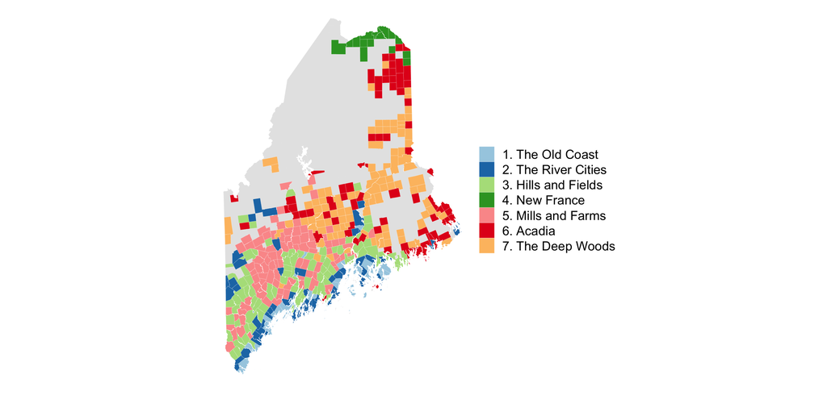

What does this map mean? What can it tell me about voting patterns?

## Election results

Maine has a lot of referendum questions – single issues put to voters across the whole state. They cover a wide range of issues: gay marriage, transport bonds, voting rights.

Here’s an example:

“Do you want to require background checks prior to the sale or transfer of firearms between individuals not licensed as firearms dealers, with failure to do so punishable by law, and with some exceptions for family members, hunting, self-defense, lawful competitions, and shooting range activity?”

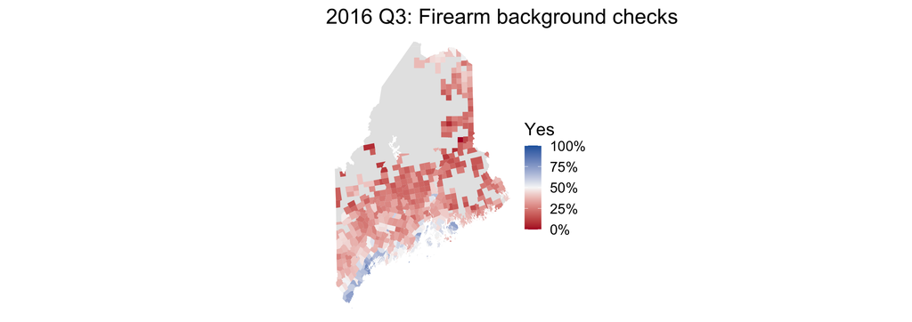

## From a map to a vector

We can make the election returns (Yes/No votes) into a vector of data, one entry per town in alphabetical order.

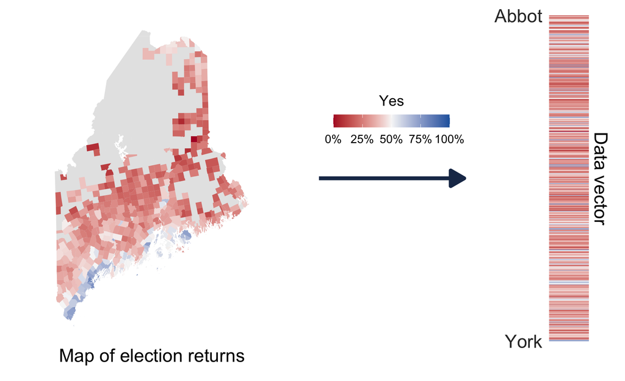

## Taking towns as rows and questions as columns:

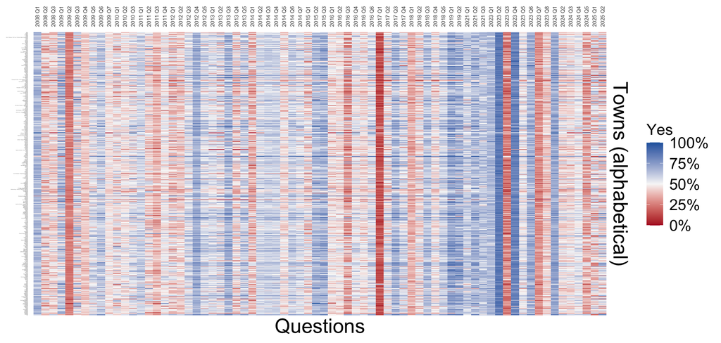

462 towns × 72 questions : 2008-2025

## What’s a voting bloc?

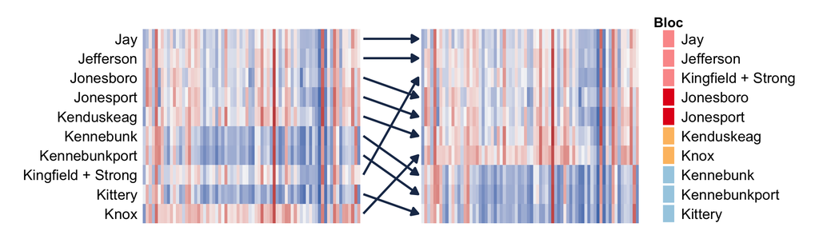

- We apply a clustering algorithm to find which towns’ voting patterns are similar to each other.
- We call a cluster of towns with similar patterns a **voting bloc**.

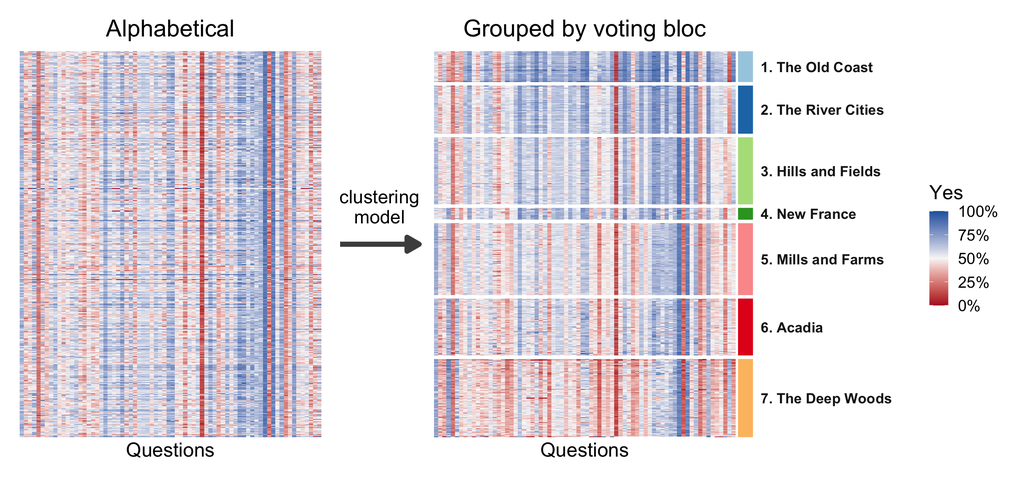

The model identifies 7 voting blocs.  
It does this from the votes alone: it doesn’t know anything else about the towns.

## Mapping it back

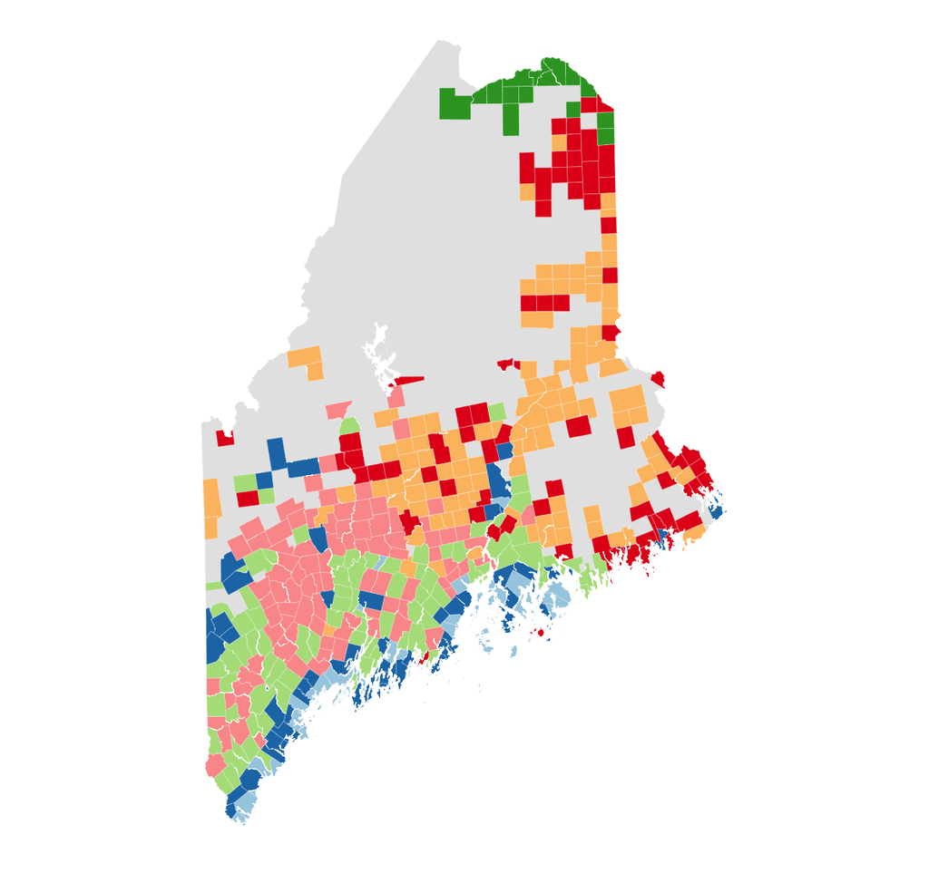

|  |  | Voting Bloc | Trump% | Example | Description |
| --- | --- | --- | --- | --- | --- |
|  | 1 | The Old Coast | 26% | Portland | Old, coastal communities |
|  | 2 | The River Cities | 39% | Augusta | Service-center cities/towns |
|  | 3 | Hills and Fields | 51% | Norway | Former truck farms and mills |
|  | 4 | New France | 57% | Madawaska | The St. John Valley |
|  | 5 | Mills and Farms | 60% | Lisbon | Mill towns and farms |
|  | 6 | Acadia | 62% | Presque Isle | The County+a bit Downeast |
|  | 7 | The Deep Woods | 72% | Jackman | Small, rural towns in the forest |

- The clusters show strong spatial structure!
- They also have a lot of demographic distinctions.

This is pretty amazing since we only told it information about voting!

## Blocs are not just partisanship

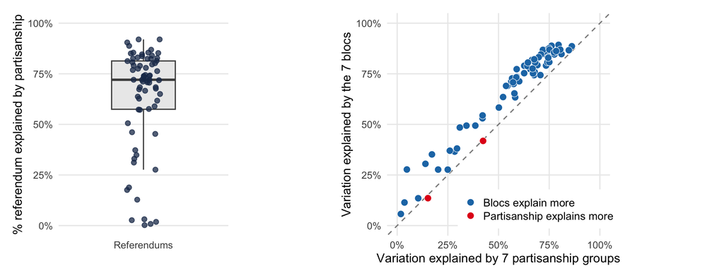

- Partisanship here means recent national elections.
- On the left: most questions have a degree of partisanship but the degree varies widely across questions.
- On the right: voting blocs beat partisanship on 70/72 questions.

## What do we see?

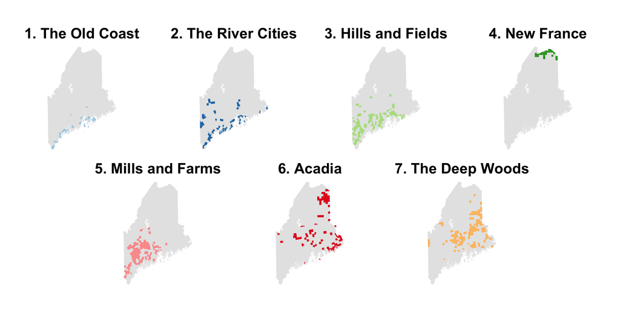

Let’s look a little closer at a few of the blocs…

## 1. The Old Coast

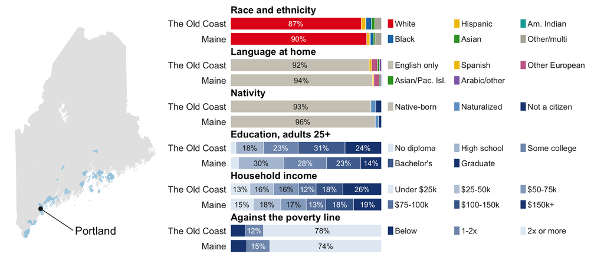

The Old Coast forms one pole of Maine politics: the affluent, old coastal towns including Portland, Kennebunk, and Camden. The wealthiest and most educated, these communities vote Democratic in tight lock-step.

## 4. New France

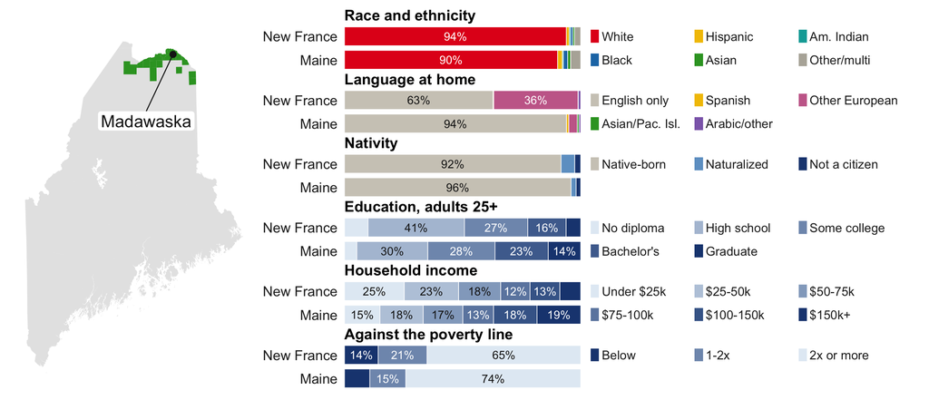

New France forms another distinct bloc – the French-speaking communities in the far north. Poorer and less educated than any other bloc, it is ideologically diverse, siding with the Old Coast on some issues and the inland blocs on others.

## 3. Hills and Fields

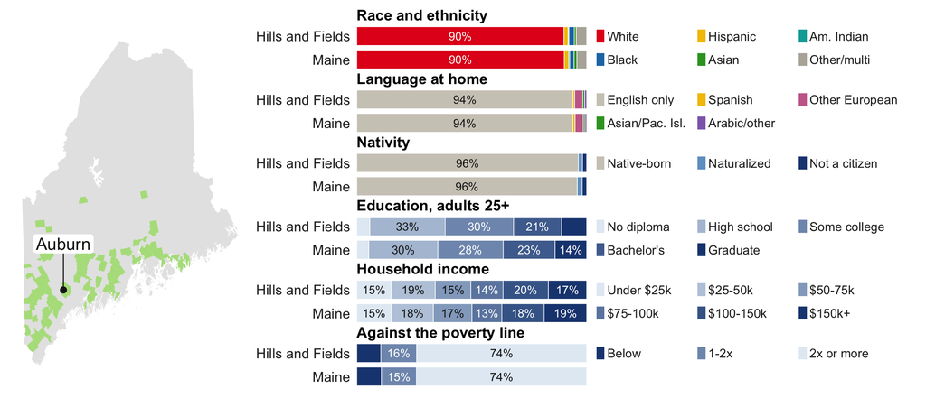

The Hills and Fields is the center bloc of Maine politics – in line with the state averages in most political and demographic features. These communities often used to be agricultural but have shifted to service/logistics hubs in the 21st century.

## Mapping the data vectors with voting blocs

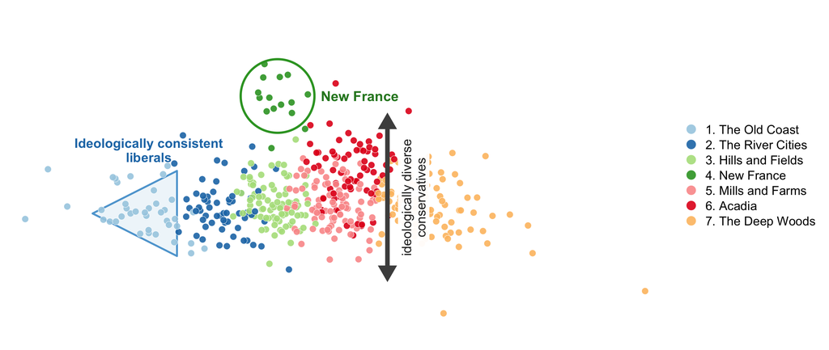

We can measure the distance between the original data vectors to see how they connect to each other. Coloring the towns by voting bloc shows us the essential features of Maine politics: the consistent liberals on the left and diverse conservatives on the right, with New France separate but in the middle.

## What happens when the model doesn’t fit well?

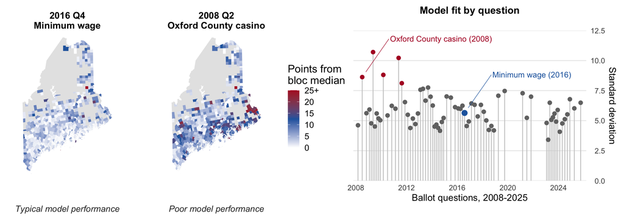

- Most questions look like minimum wage: the model gets it within 5 points for most communities. Poor performance in very small towns, which is expected: with 150 voters, a 5-point miss is ordinary chance.
- Casino questions “break” the model: suddenly blocs are broken and people are voting along different spatial patterns. This almost always happens with location-based questions.
- Turns out **some** politics is local, and we can quantify when.

## What the blocs say about the future

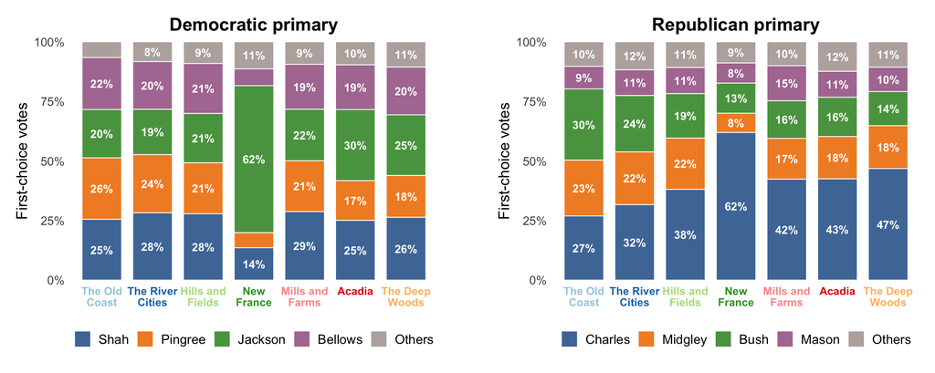

The voting blocs endure across years so we can use them to understand the performance of candidates in the future. They can also help us design better polls, understand how coalitions form and fracture, and follow changes within political parties. It also makes for an accessible way of talking about politics beyond party identification.

## Voting bloc analysis summary

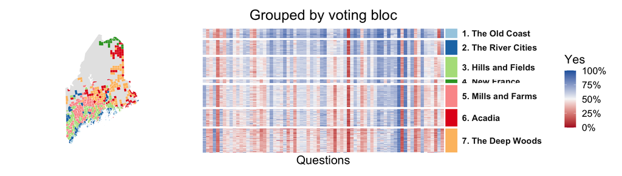

- We can infer voting blocs from election records.
- These blocs are highly spatial, and show distinct demographic cleavages.
- When the blocs fail is often very interesting!
- The blocs persist across election cycles.

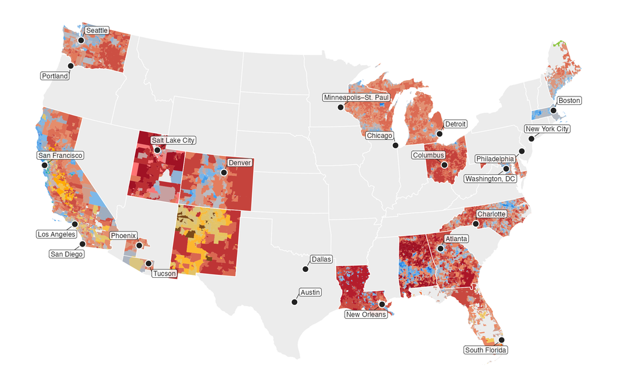

[More places: the Atlas of US Voting Blocs](https://cascobayesian.github.io/research/atlas.html)

## Why seven blocs?

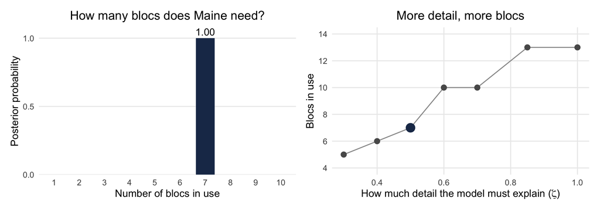

The model is allowed more blocs than it needs, and leaves the extras empty: all of the posterior weight falls on seven.  
The number does depend on how much fine detail we ask it to explain. Seven is the answer at a moderate setting.

## How sure is the model?

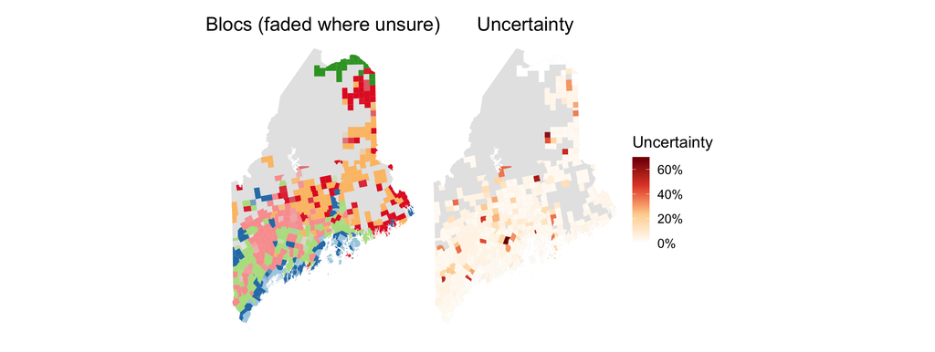

The model gives each town a probability of belonging to each bloc. Most towns are clear-cut: two-thirds are at least 95% certain.  
The uncertain towns sit between neighbouring blocs, such as Mills and Farms and Hills and Fields, never between opposite ends.

Turn your phone sideways to see the slides full size, or pinch to zoom.